# RelatorioFinal

Rodolfo Viana

23-04-2015

Segundo a Agência Nacional de Aviação Civil (Anac), às 5 maiores companhias aéreas do Brasil são:

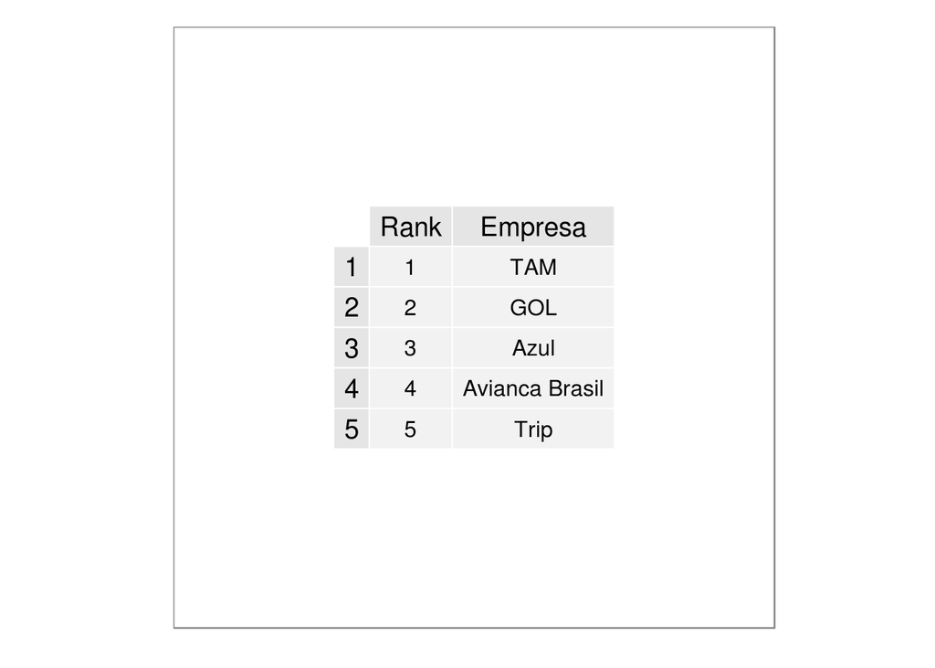

```r
library(gridExtra)
library(dplyr)
library(ggplot2)
empresasAerea <- data.frame(Rank = c(1, 2, 3, 4, 5),  Empresa = c("TAM", "GOL", "Azul", "Avianca Brasil", "Trip"))
qplot(1:5, 1:5, geom = "blank") +
  theme_bw() +
  theme(line = element_blank(),
        text = element_blank()) +
 annotation_custom(grob = tableGrob(empresasAerea, gpar.coltext = gpar(cex = 1.2), gpar.rowtext = gpar(cex = 1.2)), xmin = -Inf, xmax = Inf, ymin = -Inf, ymax = Inf) + coord_fixed()
```

Por esse motivo investiquei se os nosso parlamentares compram passagens apenas de uma ou outra empresa aérea ou se todas as grandes empresas aéreas são beneficiadas. Para isso utilizei os dados disponíveis no portal da transparência da câmara dos deputados do ano de 2015.

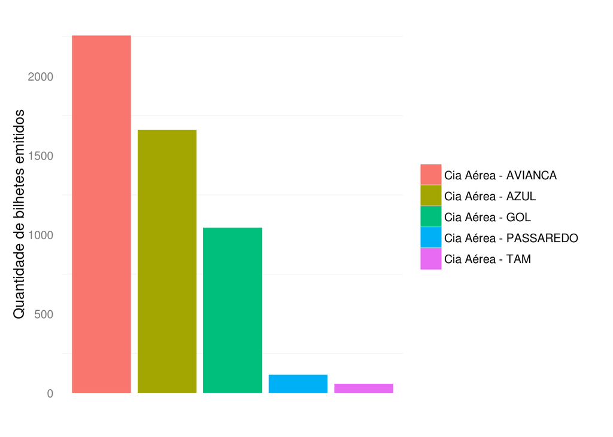

```r
file <- read.csv("AnoAtual.csv")

fileIdBeneficiario <- select(file, numSubCota, txtBeneficiario)
fileIdBeneficiario <- filter(fileIdBeneficiario, numSubCota == 999)
empresaAerea <- fileIdBeneficiario$txtBeneficiario
empresaAerea <- as.character(empresaAerea)
frameEmpresaAerea <- as.data.frame(table(empresaAerea))
ggplot(frameEmpresaAerea, aes(x=reorder(empresaAerea, -Freq), y=Freq, fill = empresaAerea)) +
  geom_bar(stat="identity") +
  labs(y='Quantidade de bilhetes emitidos') +
  theme(axis.text.x = element_text(angle = 45, hjust = 1), panel.background=element_blank(),
  legend.title=element_blank(), axis.text.x=element_blank(), axis.line=element_blank(), axis.title.x=element_blank(), axis.ticks=element_blank()) +
  scale_x_discrete(breaks = 1:5)
```

É possivel notar que a grande favorita pelos nossos parlamentares é a empresa aérea Avianca, seguida pela empresa Azul. Um fator interesante nessa analise foi o aparecimento da empresa PASSAREDO em quarto lugar. Já a empresa TAM que é considerada a maior empresa aérea do Brasil ocupando apenas o quinto lugar. Nenhuma outra empresa aérea apareceu nos dados analisados.

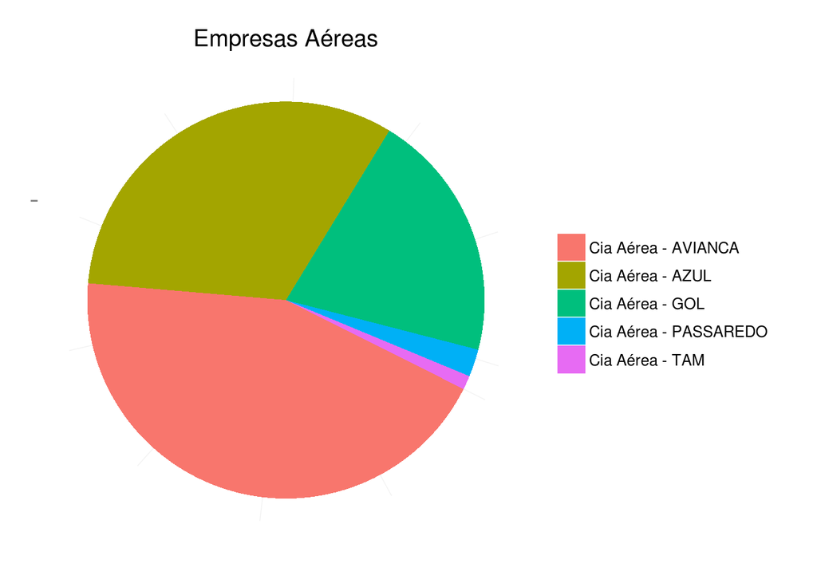

```r
frameEmpresaAerea$Freq <- as.numeric(frameEmpresaAerea$Freq)
ggplot(frameEmpresaAerea, aes(x = "", y = Freq, fill = empresaAerea)) +
  geom_bar(width = 1, stat = "identity") +
  coord_polar("y", start = 90, direction = 1) +
  labs(title = "Empresas Aéreas") +
  theme(axis.text.x=element_blank(), legend.title=element_blank(), axis.title.x=element_blank(), axis.title.y=element_blank(), panel.background=element_blank())
```

É possivel notar no gráfico acima que as empresas Avianca e Azul dominam a preferência dos parlamentares.

Ainda levando em conta os bilhetes aéreos, fiz uma analise para saber quais são os 10 parlamentares que mais utilizaram esse recurso. Levando em consideração os dados que estão no portal da transparência da câmara dos deputados do ano de 2015.

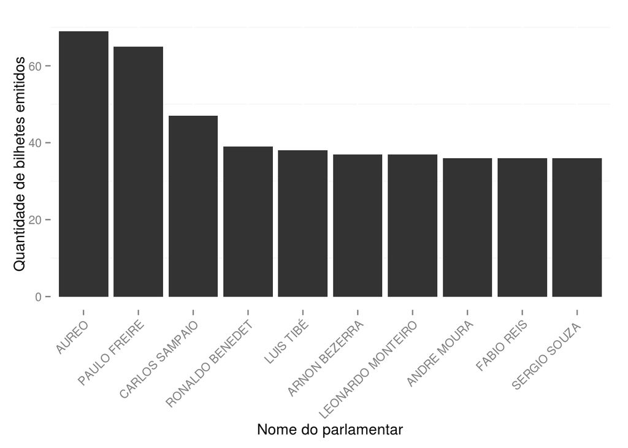

```r
fileparlamentar <- select(file, numSubCota, txNomeParlamentar)
bilheteaereo <- filter(fileparlamentar, numSubCota == 999)

bilheteaereo <- bilheteaereo$txNomeParlamentar
bilheteaereo <- as.character(bilheteaereo)
bilheteaereo <- as.data.frame(table(bilheteaereo))
bilheteaereo <- bilheteaereo[order(-bilheteaereo$Freq),]
bilheteaereohead <- head(bilheteaereo, 10)
ggplot(bilheteaereohead, aes(x=reorder(bilheteaereo, -Freq), y=Freq)) +
  geom_bar(stat="identity") +
  labs(x='Nome do parlamentar', y='Quantidade de bilhetes emitidos') +
  theme(axis.text.x = element_text(angle = 45, hjust = 1), panel.background=element_blank())
```

É possivel notar que os parlamentares Aureo e Paulo Freire já emitiram mais de 60 bilhetes aéreos cada. O parlamentar Aureo até o momento tem 69 bilhetes e o parlamentar Paulo Freire tem 65.

Para se ter uma visão geral da quantidade de bilhetes aéreos emitidos por cada parlamentar é importante observar o próximo gráfico. Onde cada ponto no gráfico representa um parlamentar.

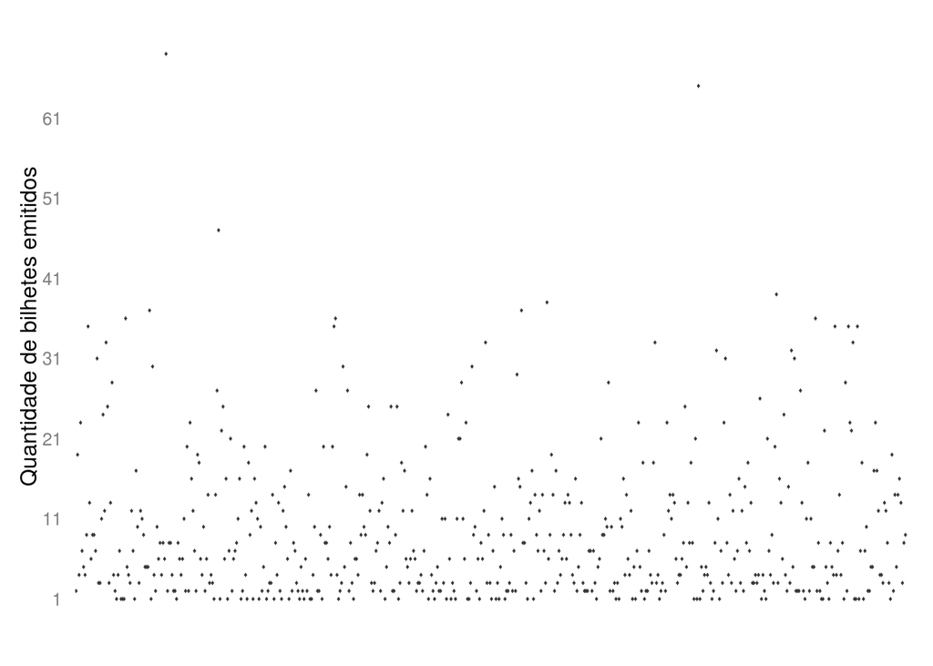

```r
ggplot(bilheteaereo, aes(x=bilheteaereo, y=Freq)) + geom_boxplot( stat = "boxplot") +
  labs(x='Parlamentar', y='Quantidade de bilhetes emitidos') +
  theme(panel.background=element_blank(),
        legend.title=element_blank(), axis.line=element_blank(), axis.text.x=element_blank(), axis.title.x=element_blank(), axis.ticks=element_blank()) +
  scale_y_continuous(breaks = round(seq(min(bilheteaereo$Freq), max(bilheteaereo$Freq), by = 10),))
```

Com esse gráfico acima é possível notar que a grande maioria dos parlamentares compraram menos de 11 bilhetes aéreos em 2015. Podemos observar também que apenas 27 parlamentares compraram mais de 30 bilhetes aéreos.

Para se ter uma melhor visão desses dados, observe o próximo gráfico.

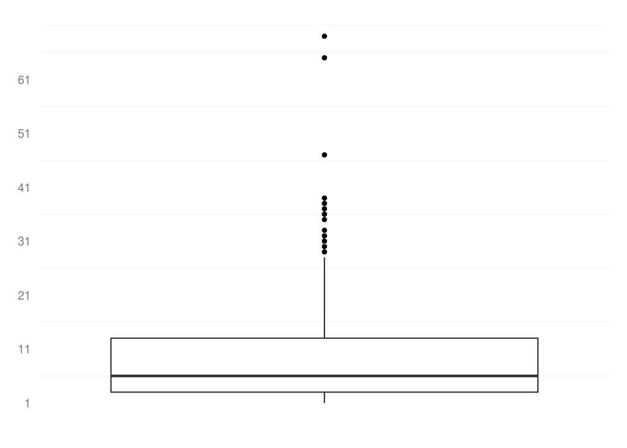

```r
boxbilhete <- bilheteaereo
boxbilhete["Col"] <- "Parlamentar"
boxbilhete$bilheteaereo <- NULL
ggplot(boxbilhete, aes(y=Freq, x=Col)) + geom_boxplot( stat = "boxplot")  +
  theme(panel.background=element_blank(),
        legend.title=element_blank(), axis.text.x=element_blank(), axis.title.y=element_blank(), axis.line=element_blank(),
        axis.title.x=element_blank(), axis.ticks=element_blank()) +
  scale_y_continuous(breaks = round(seq(min(boxbilhete$Freq), max(boxbilhete$Freq), by = 10),))
```

No boxplot acima é possível ter uma melhor visão dos bilhetes emitidios. Podemos afimar que a maioria dos parlamentares, 75%, comparam menos de 14 bilhetes cada.

Para tirar mais informações sobre esse gráfico acima é necessário fazer um “zoom”

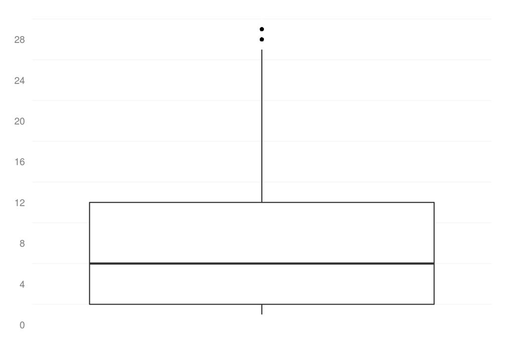

```r
ggplot(boxbilhete, aes(y=Freq, x=Col)) + geom_boxplot( stat = "boxplot")  +
  theme(panel.background=element_blank(),
        legend.title=element_blank(), axis.text.x=element_blank(), axis.title.y=element_blank(), axis.line=element_blank(), axis.title.x=element_blank(), axis.ticks=element_blank()) +
  scale_y_continuous(breaks = round(seq(0, 30, by = 4),), limits = c(0, 29))
```

Quando um parlamentar estoura a sua cota mensal ele paga o valor que ecedeu do proprio bolso. Fiquei curioso em saber se normalmente um parlamentar estoura a sua cota ou não, em caso positivo quanto que ele já gastou em 2015. Abaixo a lista dos 15 parlamentares que mais ecederam a cota mensal e tiveram que gastar dinheiro do proprio bolso.

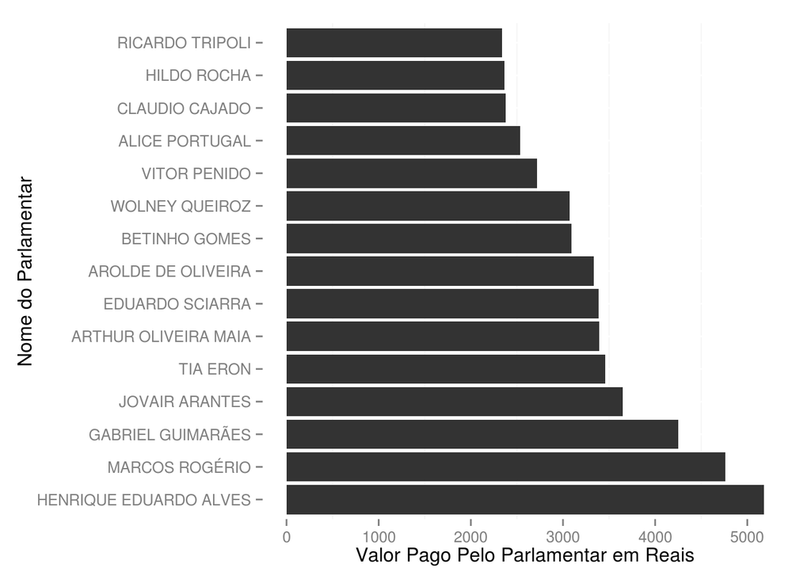

```r
filevlrGlosa <- select(file, vlrGlosa, txNomeParlamentar)
groupbyParlamentar <-  group_by(filevlrGlosa, txNomeParlamentar)
parlamentarVlrGlosa <- summarise(groupbyParlamentar, sum(vlrGlosa))
colnames(parlamentarVlrGlosa) <- c("Parlamentar", "glosa")

parlamentarVlrGlosaOrder <- parlamentarVlrGlosa[order(-parlamentarVlrGlosa$glosa),]
parlamentarVlrGlosaHead <- head(parlamentarVlrGlosaOrder, 15)
ggplot(parlamentarVlrGlosaHead, aes(x=reorder(Parlamentar, -glosa), y=glosa)) + geom_bar(stat="identity") +
  labs(x='Nome do Parlamentar', y='Valor Pago Pelo Parlamentar em Reais') +
  theme(panel.background=element_blank()) +
  coord_flip()
```

Com mais algumas analises é possivel notar que esses parlamantares na verdade são exceção. Até 25% dos parlamentares gastaram 0 reais, até 50% dos parlamentares gastaram 34,01 reais. A media geral de todos os parlamentares é igual a 272,70.

```r
summary(parlamentarVlrGlosa$glosa)
```

```
##    Min. 1st Qu.  Median    Mean 3rd Qu.    Max.
##    0.00    0.00   34.01  272.70  246.40 5181.00
```

Ao analisar o documento de cota para exercicio da ativdade parlamentar, é possivel notar que as despesas podem ser de 17 tipos diferentes:

```r
itemDescricao <- select(file, txtDescricao, numSubCota)
itemDescricaoOrder <- itemDescricao[!duplicated(itemDescricao),]
itemDescricaoOrder <- itemDescricaoOrder[order(itemDescricaoOrder$numSubCota), ]
colnames(itemDescricaoOrder) <- c("Despesa", "Tipo")
itemDescricaoOrder <- select(itemDescricaoOrder, Tipo, Despesa)
print(itemDescricaoOrder, row.names = FALSE)
```

```
##  Tipo                                                   Despesa
##     1 MANUTENÇÃO DE ESCRITÓRIO DE APOIO À ATIVIDADE PARLAMENTAR
##     3                             COMBUSTÍVEIS E LUBRIFICANTES.
##     4             CONSULTORIAS  PESQUISAS E TRABALHOS TÉCNICOS.
##     5                      DIVULGAÇÃO DA ATIVIDADE PARLAMENTAR.
##     8  SERVIÇO DE SEGURANÇA PRESTADO POR EMPRESA ESPECIALIZADA.
##     9                                          PASSAGENS AÉREAS
##    10                                                 TELEFONIA
##    11                                          SERVIÇOS POSTAIS
##    12                                 ASSINATURA DE PUBLICAÇÕES
##    13                FORNECIMENTO DE ALIMENTAÇÃO DO PARLAMENTAR
##    14    HOSPEDAGEM  EXCETO DO PARLAMENTAR NO DISTRITO FEDERAL.
##   119                        LOCAÇÃO OU FRETAMENTO DE AERONAVES
##   120             LOCAÇÃO OU FRETAMENTO DE VEÍCULOS AUTOMOTORES
##   121                      LOCAÇÃO OU FRETAMENTO DE EMBARCAÇÕES
##   122                 SERVIÇO DE TÁXI  PEDÁGIO E ESTACIONAMENTO
##   123               PASSAGENS TERRESTRES  MARÍTIMAS OU FLUVIAIS
##   999                                     Emissão Bilhete Aéreo
```

É possivel notar que os nossos parlamentares gastam mais recuros da cota nos itens: **DIVULGAÇÃO DA ATIVIDADE PARLAMENTAR**, **LOCAÇÃO OU FRETAMENTO DE VEÍCULOS AUTOMOTORES** e **MANUTENÇÃO DE ESCRITÓRIO DE APOIO À ATIVIDADE PARLAMENTAR**

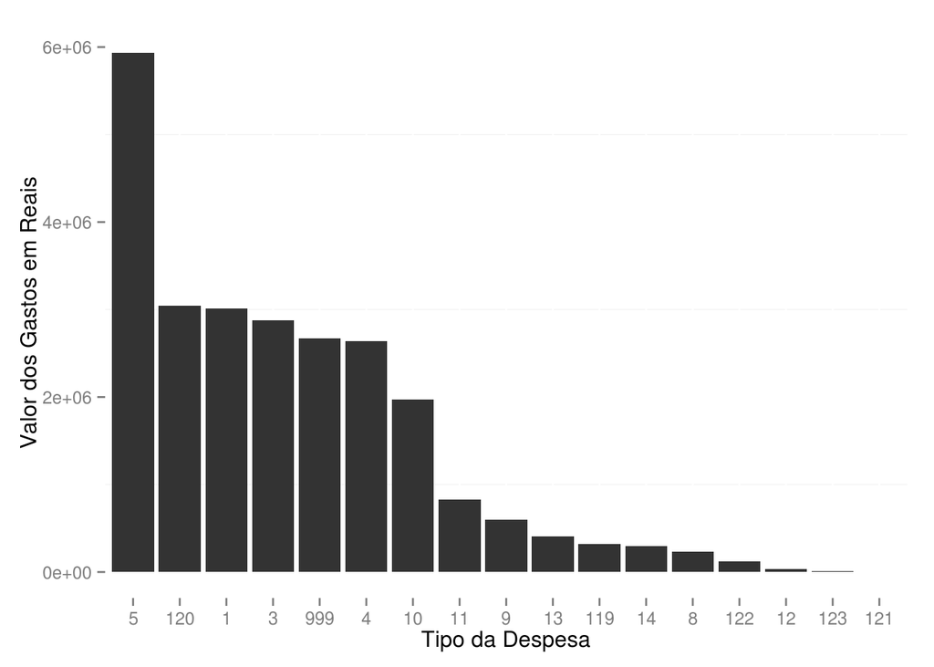

```r
groupedByNumSubCota <- group_by(file, numSubCota)
valorLiquido <- summarise(groupedByNumSubCota, sum(vlrLiquido))
colnames(valorLiquido) <- c("Tipo", "Descricao")
valorLiquido <- valorLiquido[order(valorLiquido$Descricao), ]
valorLiquido$Tipo <- as.character(valorLiquido$Tipo)
ggplot(valorLiquido, aes(x=reorder(Tipo, -Descricao), y=Descricao)) + geom_bar(stat = "identity") + labs(x='Tipo da Despesa', y='Valor dos Gastos em Reais') + theme(panel.background=element_blank())
```

Como **MANUTENÇÃO DE ESCRITÓRIO DE APOIO À ATIVIDADE PARLAMENTAR** é dos itens que os parlamentares gastam mais recursos da cota, achei esencial investigar isso melhor. Segundo o portal da transparência o parlamentar pode gastar esse recurso da seguinte forma: compreendendo locação de imóveis, pagamento de taxa de condomínio, IPTU, energia elétrica, água e esgoto, locação de móveis e equipamentos, material de expediente e suprimentos de informática, acesso à internet, assinatura de TV a cabo ou similar, locação ou aquisição de licença de uso de software, assinatura de publicações. A lista das 10 empresas que mais lucraram com esse recurso foram:

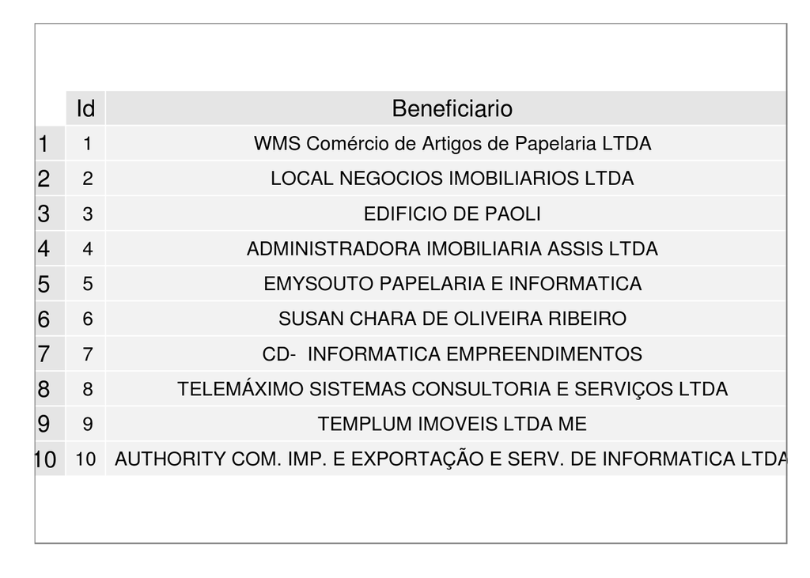

```r
fileEscritorioValor <- select(file, numSubCota, txtBeneficiario, vlrLiquido)
fileEscritorioValor <- filter(fileEscritorioValor, numSubCota == 1)

groupbyEscritorioValor <-  group_by(fileEscritorioValor, txtBeneficiario)
tipoDespesaVlrliquido <- summarise(groupbyEscritorioValor, sum(vlrLiquido))
colnames(tipoDespesaVlrliquido) <- c("Beneficiario", "Valor")
tipoDespesaVlrliquido <- tipoDespesaVlrliquido[order(-tipoDespesaVlrliquido$Valor),]
tipoDespesaVlrliquidoHead <- head(tipoDespesaVlrliquido, 10)
tipoDespesaVlrliquidoHead["Id"] <- c(1:10)

frameBeneficiarioId <- select(tipoDespesaVlrliquidoHead, Id, Beneficiario)
qplot(1:10, 1:10, geom = "blank") +
  theme_bw() +
  theme(line = element_blank(),
        text = element_blank()) +
 annotation_custom(grob = tableGrob(frameBeneficiarioId,
                                   gpar.coltext = gpar(cex = 1.2),
                                   gpar.rowtext = gpar(cex = 1.2)),
                  xmin = -Inf, xmax = Inf, ymin = -Inf, ymax = Inf)
```

O valor que cada uma dessas empresas lucraram em 2015, são:

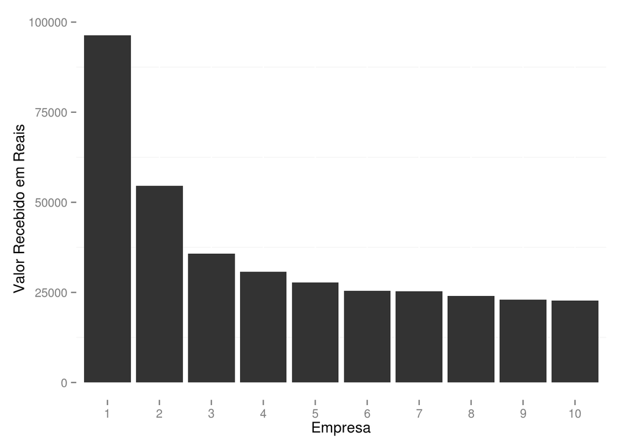

```r
ggplot(tipoDespesaVlrliquidoHead, aes(x=reorder(Id, -Valor), y=Valor)) + geom_bar(stat="identity") + labs(x='Empresa', y='Valor Recebido em Reais') +
  theme(panel.background=element_blank()) + theme(panel.background=element_blank())
```

Os tipos de despesas que mais variam e que portanto são mais desiguais são: **DIVULGAÇÃO DA ATIVIDADE PARLAMENTAR**, **CONSULTORIAS PESQUISAS E TRABALHOS TÉCNICOS** e **LOCAÇÃO OU FRETAMENTO DE AERONAVES**

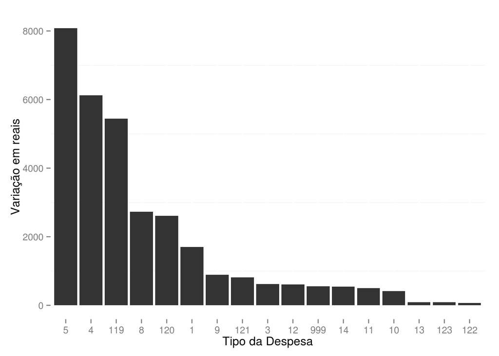

```r
desvio <- summarise(groupedByNumSubCota, sd(vlrLiquido))
colnames(desvio) <- c("Tipo", "Desvio")
desvio$Tipo <- as.character(desvio$Tipo)
ggplot(desvio, aes(x=reorder(Tipo, -Desvio), y=Desvio)) + geom_bar(stat = "identity") + labs(x='Tipo da Despesa', y='Variação em reais') + theme(panel.background=element_blank())
```

O valor ficou alto para esses tipos de despesas pois a variação dos valores dos gastos dessas despesas são altos. Quanto mais proximo de zero mais uniforme são os gastos.

Fonte do documento: http://www2.camara.leg.br/transparencia/cota-para-exercicio-da-atividade-parlamentar/dados-abertos-cota-parlamentar

Mais explicações sobre o documento: http://www2.camara.leg.br/transparencia/cota-para-exercicio-da-atividade-parlamentar/explicacoes-sobre-o-formato-dos-arquivos-xml